# Community ecology - Computer lab III - AB332

Anders K. Krabberød (UiO) and Ramiro Logares (ICM)

October 2023

# Computer lab III

### First load the necessary packages.

Load data from previous lab (if it is not already in the environment)

```r
load("AB332_lab_II.RData")
```

### Analyses using environmental variation

The aim is to investigate how the environmental variation may explain community variance.  
**Read table with environmental data**:

```r
isa.metadata<-read_tsv("https://raw.githubusercontent.com/krabberod/UNIS_AB332_2023/main/computer_lab/data/AB332metadata_v3.txt")
isa.metadata
```

| Sample_Name | date | year | season_nr | seasons | month | day | DOY | running_day | template | depth | declination | daylength | nitrate | phosphate | silicate | N_P | watermass | temp_25 | sal_25 | F_25 | chla_GFF | chla_10 | chl_small | bacteria | virus |
| --- | --- | --- | --- | --- | --- | --- | --- | --- | --- | --- | --- | --- | --- | --- | --- | --- | --- | --- | --- | --- | --- | --- | --- | --- | --- |
| Isa_111214 | 14-Dec-11 | 2011 | 1 | winter | 12 | 14 | 348 | 348 | 1 | 25 | -23.06 | 0 | 2.810 | 0.150 | 1.510 | 18.8 | 5 | 0.8665000 | 34.31500 | 0.000000000 | 0.02400000 | 0.003000000 | 0.020000 | NA | NA |
| Isa_120117 | 17-Jan-12 | 2012 | 1 | winter | 1 | 17 | 17 | 382 | 1 | 25 | -20.68 | 0 | NA | NA | NA | NA | 5 | -1.3075000 | 34.18160 | 0.036630000 | 0.04000000 | 0.010341667 | 0.029000 | NA | NA |
| Isa_120128 | 28-Jan-12 | 2012 | 1 | winter | 1 | 28 | 28 | 393 | 1 | 25 | -18.22 | 0 | 7.220 | 0.300 | 4.480 | 23.9 | 5 | -0.8325000 | 34.23750 | 0.000000000 | 0.03640833 | 0.015866667 | 0.021000 | NA | NA |
| Isa_120209 | 09-Feb-12 | 2012 | 1 | winter | 2 | 9 | 40 | 405 | 1 | 25 | -14.76 | 0 | 7.320 | 0.360 | 4.580 | 20.5 | 5 | -0.7807500 | 34.17000 | 0.000000000 | 0.03017500 | 0.008358333 | 0.022000 | NA | NA |
| Isa_120216 | 16-Feb-12 | 2012 | 1 | winter | 2 | 16 | 47 | 412 | 1 | 25 | -12.43 | 0 | 5.520 | 0.250 | 2.650 | 22.2 | 5 | -0.6090000 | 34.30400 | 0.000000000 | 0.03017500 | 0.006800000 | 0.023000 | 6323007 | 88637636 |
| Isa_120223 | 23-Feb-12 | 2012 | 1 | winter | 2 | 23 | 54 | 419 | 1 | 25 | -9.92 | 5 | 6.850 | 0.420 | 3.940 | 16.4 | 5 | -0.3365000 | 34.34000 | 0.000000000 | 0.01501667 | 0.005950000 | 0.009000 | 25569416 | 160216949 |
| Isa_120301 | 01-Mar-12 | 2012 | 2 | spring | 3 | 1 | 61 | 426 | 1 | 25 | -7.66 | 7 | 6.380 | 0.500 | 3.200 | 12.7 | 3 | 1.3284000 | 34.62000 | 0.000000000 | 0.02096667 | 0.010341667 | 0.011000 | 35347574 | 236494102 |
| Isa_120308 | 08-Mar-12 | 2012 | 2 | spring | 3 | 8 | 68 | 433 | 1 | 25 | -4.52 | 9 | 3.980 | 0.330 | 1.950 | 12.2 | NA | 1.1212000 | 34.61750 | 0.000000000 | 0.01501667 | 0.008500000 | 0.007000 | 460490 | 14842982 |
| Isa_120320 | 20-Mar-12 | 2012 | 2 | spring | 3 | 20 | 80 | 445 | 1 | 25 | 0.32 | 12 | 9.390 | 0.660 | 5.500 | 14.3 | 5 | 0.9140000 | 34.61500 | 0.000000000 | 0.01317500 | 0.010058333 | 0.003000 | 3067808 | 122004027 |
| Isa_120321 | 21-Mar-12 | 2012 | 2 | spring | 3 | 21 | 81 | 446 | 1 | 25 | 0.72 | 12 | 4.820 | 0.470 | 2.300 | 10.3 | 2 | 1.3662500 | 34.71000 | 0.000000000 | 0.01671667 | 0.008925000 | 0.008000 | 361644 | 3937919 |

[output cut: 72 more lines]

```r
isa.metadata <- column_to_rownames(isa.metadata, var = "Sample_Name")
```

Check the variables available in the metadata:

```r
colnames(isa.metadata)
```

```
 [1] "date"        "year"        "season_nr"   "seasons"     "month"       "day"         "DOY"         "running_day" "template"
[10] "depth"       "declination" "daylength"   "nitrate"     "phosphate"   "silicate"    "N_P"         "watermass"   "temp_25"
[19] "sal_25"      "F_25"        "chla_GFF"    "chla_10"     "chl_small"   "bacteria"    "virus"
```

Select the environmental variables for the same samples as we have been using for the previous labs.

```r
isa.metadata.simp <- isa.metadata[6:30,]
isa.metadata.simp
```

|  | date | year | season_nr | seasons | month | day | DOY | running_day | template | depth | declination | daylength | nitrate | phosphate | silicate | N_P | watermass | temp_25 | sal_25 | F_25 | chla_GFF | chla_10 | chl_small | bacteria | virus |
| --- | --- | --- | --- | --- | --- | --- | --- | --- | --- | --- | --- | --- | --- | --- | --- | --- | --- | --- | --- | --- | --- | --- | --- | --- | --- |
| Isa_120223 | 23-Feb-12 | 2012 | 1 | winter | 2 | 23 | 54 | 419 | 1 | 25 | -9.92 | 5 | 6.85 | 0.42 | 3.94 | 16.4 | 5 | -0.3365000 | 34.34000 | 0.00000000 | 0.01501667 | 0.005950000 | 0.009000 | 25569416 | 160216949 |
| Isa_120301 | 01-Mar-12 | 2012 | 2 | spring | 3 | 1 | 61 | 426 | 1 | 25 | -7.66 | 7 | 6.38 | 0.50 | 3.20 | 12.7 | 3 | 1.3284000 | 34.62000 | 0.00000000 | 0.02096667 | 0.010341667 | 0.011000 | 35347574 | 236494102 |
| Isa_120308 | 08-Mar-12 | 2012 | 2 | spring | 3 | 8 | 68 | 433 | 1 | 25 | -4.52 | 9 | 3.98 | 0.33 | 1.95 | 12.2 | NA | 1.1212000 | 34.61750 | 0.00000000 | 0.01501667 | 0.008500000 | 0.007000 | 460490 | 14842982 |
| Isa_120320 | 20-Mar-12 | 2012 | 2 | spring | 3 | 20 | 80 | 445 | 1 | 25 | 0.32 | 12 | 9.39 | 0.66 | 5.50 | 14.3 | 5 | 0.9140000 | 34.61500 | 0.00000000 | 0.01317500 | 0.010058333 | 0.003000 | 3067808 | 122004027 |
| Isa_120321 | 21-Mar-12 | 2012 | 2 | spring | 3 | 21 | 81 | 446 | 1 | 25 | 0.72 | 12 | 4.82 | 0.47 | 2.30 | 10.3 | 2 | 1.3662500 | 34.71000 | 0.00000000 | 0.01671667 | 0.008925000 | 0.008000 | 361644 | 3937919 |
| Isa_120322 | 22-Mar-12 | 2012 | 2 | spring | 3 | 22 | 82 | 447 | 1 | 25 | 1.12 | 13 | 4.26 | 0.39 | 1.90 | 10.8 | 2 | 1.9827500 | 34.77250 | 0.00000000 | 0.02054167 | 0.009491667 | 0.011000 | 293220 | 5671576 |
| Isa_120323 | 23-Mar-12 | 2012 | 2 | spring | 3 | 23 | 83 | 448 | 1 | 25 | 1.52 | 13 | 8.23 | 0.54 | 4.97 | 15.2 | 3 | 1.2695000 | 34.68500 | 0.00000000 | 0.01877083 | 0.010695834 | 0.008075 | 624099 | 18447977 |
| Isa_120329 | 29-Mar-12 | 2012 | 2 | spring | 3 | 29 | 89 | 454 | 1 | 25 | 3.92 | 14 | 7.59 | 0.86 | 3.52 | 8.9 | 2 | 1.9096667 | 34.79000 | 0.00000000 | 0.01700000 | 0.011900000 | 0.005000 | 334140 | 3851871 |
| Isa_120403 | 03-Apr-12 | 2012 | 2 | spring | 4 | 3 | 94 | 459 | 1 | 25 | 5.88 | 16 | 4.87 | 0.54 | 2.35 | 9.0 | 2 | 1.2520000 | 34.73500 | 0.00000000 | 0.04774167 | 0.024791667 | 0.023000 | 328804 | 4615040 |
| Isa_120411 | 11-Apr-12 | 2012 | 2 | spring | 4 | 11 | 102 | 467 | 1 | 25 | 8.91 | 18 | 9.02 | 0.70 | 4.10 | 12.9 | 2 | 1.4846667 | 34.83667 | 0.01500000 | 0.11928333 | 0.060916667 | 0.058000 | 43950699 | 137057832 |

[output cut: 15 more lines]

Check that the samples are correct, i.e. that the same names are in the OTU-table and the metadata:

```r
identical(colnames(otu.tab.red),rownames(isa.metadata.simp))
```

```
[1] TRUE
```

For this exercise we will use a selection of the continuous variables as metadata.  
This line will extract 8 of the variables, based on the column names:

```r
isa.metadata.cont <- isa.metadata.simp %>% dplyr::select("nitrate","phosphate","silicate","N_P","temp_25","sal_25","F_25","chla_GFF")
```

We transform variables using z-scores to have comparable ranges of variation.

```r
isa.metadata.cont.zscores <-scale(isa.metadata.cont, center = T, scale = T)
isa.metadata.cont.zscores[1:5,]
```

```
              nitrate  phosphate    silicate       N_P    temp_25     sal_25       F_25   chla_GFF
Isa_120223 0.97203545  0.1823123  1.28060579 1.7160683 -1.3943371 -1.3743479 -0.7573225 -0.7194154
Isa_120301 0.81458554  0.5621295  0.76858489 0.8726235  0.3262221  0.1453681 -0.7573225 -0.7161295
Isa_120308 0.01058599 -0.2449821 -0.09631528 0.7586444  0.1120952  0.1317992 -0.7573225 -0.7194154
Isa_120320 1.82293496  1.3217639  2.36000121 1.2373564 -0.1020317  0.1182303 -0.7573225 -0.7204324
Isa_120321 0.29198583  0.4196980  0.14585677 0.3255241  0.3653375  0.6338482 -0.7573225 -0.7184765
```

Let’s check if the environmental variables are correlated to each other. We Calculate correlations and p-values:

```r
(env.corr.signif.adjust <- rcorr.adjust(as.matrix(isa.metadata.cont.zscores)))
```

```
 Pearson correlations:
          nitrate phosphate silicate     N_P temp_25  sal_25    F_25 chla_GFF
nitrate    1.0000    0.9155   0.9250  0.8363 -0.0095  0.5964 -0.5533  -0.4996
phosphate  0.9155    1.0000   0.7876  0.6361  0.0334  0.7318 -0.4471  -0.4372
silicate   0.9250    0.7876   1.0000  0.7588  0.0466  0.3808 -0.5093  -0.4968
N_P        0.8363    0.6361   0.7588  1.0000 -0.3256  0.4901 -0.4386  -0.3460
temp_25   -0.0095    0.0334   0.0466 -0.3256  1.0000 -0.1002 -0.5564  -0.4205
sal_25     0.5964    0.7318   0.3808  0.4901 -0.1002  1.0000 -0.1328  -0.0779
F_25      -0.5533   -0.4471  -0.5093 -0.4386 -0.5564 -0.1328  1.0000   0.7413
chla_GFF  -0.4996   -0.4372  -0.4968 -0.3460 -0.4205 -0.0779  0.7413   1.0000

 Number of observations: 25

 Pairwise two-sided p-values:
          nitrate phosphate silicate N_P    temp_25 sal_25 F_25   chla_GFF
nitrate           <.0001    <.0001   <.0001 0.9642  0.0017 0.0041 0.0110
phosphate <.0001            <.0001   0.0006 0.8739  <.0001 0.0250 0.0288
silicate  <.0001  <.0001             <.0001 0.8250  0.0604 0.0093 0.0115
N_P       <.0001  0.0006    <.0001          0.1122  0.0129 0.0283 0.0902
temp_25   0.9642  0.8739    0.8250   0.1122         0.6335 0.0039 0.0363
sal_25    0.0017  <.0001    0.0604   0.0129 0.6335         0.5268 0.7114
F_25      0.0041  0.0250    0.0093   0.0283 0.0039  0.5268        <.0001
chla_GFF  0.0110  0.0288    0.0115   0.0902 0.0363  0.7114 <.0001

 Adjusted p-values (Holm's method)
          nitrate phosphate silicate N_P    temp_25 sal_25 F_25   chla_GFF
nitrate           <.0001    <.0001   <.0001 1.0000  0.0330 0.0741 0.1759
phosphate <.0001            <.0001   0.0133 1.0000  0.0007 0.3256 0.3397
silicate  <.0001  <.0001             0.0003 1.0000  0.5434 0.1583 0.1759
N_P       <.0001  0.0133    0.0003          0.7852  0.1804 0.3397 0.7218
temp_25   1.0000  1.0000    1.0000   0.7852         1.0000 0.0735 0.3634
sal_25    0.0330  0.0007    0.5434   0.1804 1.0000         1.0000 1.0000
F_25      0.0741  0.3256    0.1583   0.3397 0.0735  1.0000        0.0005
chla_GFF  0.1759  0.3397    0.1759   0.7218 0.3634  1.0000 0.0005
```

The p-values are corrected for multiple inference using Holm’s method (see p.adjust). More info on: https://en.wikipedia.org/wiki/Multiple_comparisons_problem Holm corrected values for multiple comparisons

```r
env.corr.signif.r <- env.corr.signif.adjust$R$r
env.corr.signif.p <- env.corr.signif.adjust$P
# Edit the object to replace any "<" by "0" using the function "gsub"
env.corr.signif.p <- gsub("<","0", env.corr.signif.p)
# We modify the object to be numeric datatype.
# NB: the transformation is done so the matrix of p values can be read as numeric!
env.corr.signif.p <- apply(env.corr.signif.p, 2 ,as.numeric)
rownames(env.corr.signif.p) <- colnames(env.corr.signif.p)
```

Plot the correlation plot:

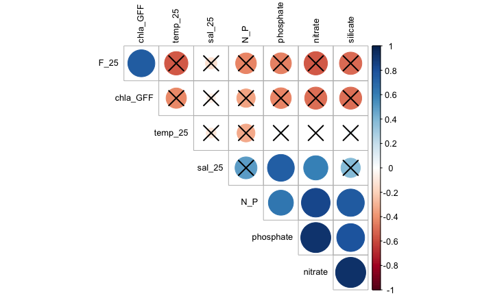

```r
corrplot(env.corr.signif.r , type="upper", order="hclust", p.mat = env.corr.signif.p, sig.level = 0.05,insig = "pch",hclust.method = c("average"), tl.cex= 0.8, tl.col="black", diag=F)
```

### Fitting environmental variables to ordinations

`envfit` will fit the environmental variables to the NMDS ordination as vectors  
First we fit the variables to the OTU-table that was rarified:

```r
otu.tab.trans.ss.nozero.bray.nmds.envfit <- envfit(otu.tab.trans.ss.nozero.bray.nmds,
                                            as.data.frame(isa.metadata.cont.zscores),  permu=999, na.rm=T, display ="sites")
otu.tab.trans.ss.nozero.bray.nmds.envfit
```

```
***VECTORS

             NMDS1    NMDS2     r2 Pr(>r)
nitrate   -0.47942  0.87758 0.7294  0.001 ***
phosphate -0.36541  0.93085 0.7835  0.001 ***
silicate  -0.64291  0.76595 0.5976  0.001 ***
N_P       -0.49425  0.86932 0.4093  0.003 **
temp_25   -0.47060 -0.88235 0.2671  0.045 *
sal_25    -0.12979  0.99154 0.6670  0.001 ***
F_25       0.83061  0.55685 0.7302  0.001 ***
chla_GFF   0.59268  0.80544 0.7190  0.001 ***
---
Signif. codes:  0 ‘***’ 0.001 ‘**’ 0.01 ‘*’ 0.05 ‘.’ 0.1 ‘ ’ 1
Permutation: free
Number of permutations: 999
```

The two last columns indicate the squared correlation coefficient and the associated p-value We plot the vectors of the significant correlations

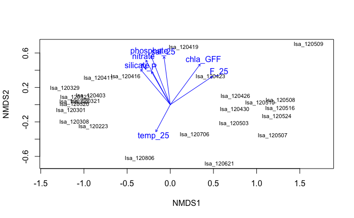

```r
plot(otu.tab.trans.ss.nozero.bray.nmds, type="t", display="sites") # plot the samples
plot(otu.tab.trans.ss.nozero.bray.nmds.envfit) # plot all environmental vectors
```

The plotting only the vectors with p<0.01.

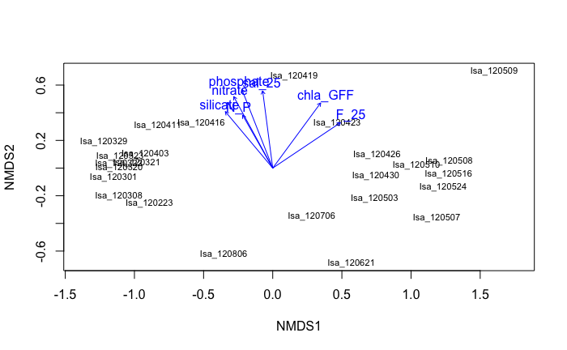

```r
plot(otu.tab.trans.ss.nozero.bray.nmds, type="t", display="sites") # plot the samples
plot(otu.tab.trans.ss.nozero.bray.nmds.envfit, p.max=0.01)
```

Can you see any difference?

## Constrained Ordination

Distance-based redundancy analysis (dbRDA) is an ordination method similar to Redundancy Analysis (rda), but it allows non-Euclidean dissimilarity indices, such as Manhattan or Bray–Curtis distance. Selection of the most important (i.e. signficant) variables for dbRDA is done by comparing a null model to the full model and doing a stepwise selection of significant variables.

Start with a model containing only species matrix and intercept:

```r
mod0.rarefaction <- capscale(otu.tab.trans.ss.nozero.bray ~ 1, as.data.frame(isa.metadata.cont.zscores))
mod0.rarefaction
```

```
Call: capscale(formula = otu.tab.trans.ss.nozero.bray ~ 1, data = as.data.frame(isa.metadata.cont.zscores))

              Inertia Rank
Total          5.6040
Unconstrained  5.6328   22
Imaginary     -0.0288    2
Inertia is squared Bray distance

Eigenvalues for unconstrained axes:
  MDS1   MDS2   MDS3   MDS4   MDS5   MDS6   MDS7   MDS8
3.1000 0.6641 0.4584 0.3506 0.3246 0.1755 0.1416 0.1076
(Showing 8 of 22 unconstrained eigenvalues)
```

Now make a model including all variables from env matrix (the dot after tilde (~) means ALL!)

```r
mod1.rarefaction <- capscale(otu.tab.trans.ss.nozero.bray ~ ., as.data.frame(isa.metadata.cont.zscores))
mod1.rarefaction
```

```
Call: capscale(formula = otu.tab.trans.ss.nozero.bray ~ nitrate + phosphate + silicate + N_P + temp_25 + sal_25 + F_25 +
chla_GFF, data = as.data.frame(isa.metadata.cont.zscores))

                Inertia Proportion Rank
Total          5.603981   1.000000
Constrained    3.915949   0.698780    8
Unconstrained  1.716829   0.306359   16
Imaginary     -0.028797  -0.005139    2
Inertia is squared Bray distance

Eigenvalues for constrained axes:
  CAP1   CAP2   CAP3   CAP4   CAP5   CAP6   CAP7   CAP8
2.6596 0.4516 0.3198 0.2105 0.1282 0.0988 0.0270 0.0205

Eigenvalues for unconstrained axes:
  MDS1   MDS2   MDS3   MDS4   MDS5   MDS6   MDS7   MDS8   MDS9  MDS10  MDS11  MDS12  MDS13  MDS14  MDS15  MDS16
0.6284 0.4014 0.1796 0.1281 0.0898 0.0758 0.0490 0.0393 0.0367 0.0267 0.0198 0.0148 0.0107 0.0086 0.0054 0.0029
```

> NB here you might get an error if you have missing values. Missing vaules can be dealt with in different ways depending on the situation. Sometimes it is easiest to drop the sample, sometimes you can imput the values of the missing data. The default in the capscale (na.fail) is to stop with missing values. Choices na.omit and na.exclude delete rows with missing values, but differ in representation of results. With na.omit only non-missing site scores are shown, but na.exclude gives NA for scores of missing observations.

Finally do the stepwise selection of variables:

```r
ordistep(mod0.rarefaction, scope = formula(mod1.rarefaction), perm.max = 1000, direction="forward")
```

```
Start: otu.tab.trans.ss.nozero.bray ~ 1

            Df    AIC       F Pr(>F)
+ F_25       1 34.840 13.2228  0.005 **
+ silicate   1 36.900 10.3566  0.005 **
+ nitrate    1 36.945 10.2968  0.005 **
+ chla_GFF   1 37.919  9.0252  0.005 **
+ phosphate  1 37.971  8.9589  0.005 **
+ N_P        1 40.869  5.4599  0.005 **
+ sal_25     1 42.894  3.2456  0.025 *
+ temp_25    1 42.589  3.5678  0.035 *
---
Signif. codes:  0 ‘***’ 0.001 ‘**’ 0.01 ‘*’ 0.05 ‘.’ 0.1 ‘ ’ 1

Step: otu.tab.trans.ss.nozero.bray ~ F_25

            Df    AIC      F Pr(>F)
+ phosphate  1 31.633 5.0941  0.005 **
+ nitrate    1 32.179 4.5083  0.005 **
+ sal_25     1 32.713 3.9487  0.005 **
+ silicate   1 31.977 4.7232  0.010 **
+ N_P        1 33.692 2.9522  0.025 *
+ chla_GFF   1 35.111 1.5746  0.175
+ temp_25    1 35.620 1.0996  0.290
---
Signif. codes:  0 ‘***’ 0.001 ‘**’ 0.01 ‘*’ 0.05 ‘.’ 0.1 ‘ ’ 1

Step: otu.tab.trans.ss.nozero.bray ~ F_25 + phosphate

           Df    AIC      F Pr(>F)
+ silicate  1 31.489 1.8801  0.095 .
+ N_P       1 31.822 1.5771  0.125
+ chla_GFF  1 31.667 1.7181  0.135
+ temp_25   1 32.029 1.3916  0.160
+ sal_25    1 32.220 1.2210  0.350
+ nitrate   1 32.731 0.7714  0.570
---
Signif. codes:  0 ‘***’ 0.001 ‘**’ 0.01 ‘*’ 0.05 ‘.’ 0.1 ‘ ’ 1

Call: capscale(formula = otu.tab.trans.ss.nozero.bray ~ F_25 + phosphate, data = as.data.frame(isa.metadata.cont.zscores))

                Inertia Proportion Rank
Total          5.603981   1.000000
Constrained    2.728646   0.486912    2
Unconstrained  2.904132   0.518227   22
Imaginary     -0.028797  -0.005139    2
Inertia is squared Bray distance

Eigenvalues for constrained axes:
  CAP1   CAP2
2.4127 0.3160

Eigenvalues for unconstrained axes:
  MDS1   MDS2   MDS3   MDS4   MDS5   MDS6   MDS7   MDS8
1.0612 0.4918 0.3523 0.2068 0.1800 0.1423 0.1246 0.0839
(Showing 8 of 22 unconstrained eigenvalues)
```

*Can you see which variables were selected?*  
When doing a stepwise building of models you can this either “forward” (as in the example), “backwards”, or “both”. Try different methods and see if the end result is any different.